# Major Project: Visualizations of African Women

PSDV-4200  
Women and Development in Africa  
Rebekah Doochin  
Fall 2020

###### About this Project

For my final project, I have used graphs and visualizations generated with data on women in African countries and recreated depictions of those trends in photographs. I think that using human models and real world objects to exhibit some of the high rates of violence and oppression against women will be a more impactful representation than computer generated graphs alone.

###### Important Information

I will be making updates to this page throughout the Fall 2020 semester. A final version of this project will be abvailable on December 2, 2020.  
Throughout this project you will notice that for many of the datasets, I have filtered out data from before the year 2010. This is because I believe that looking at the last 10 years of data will provide the most accurate insight into what the quality of life is like for women in African countries today, while still giving me enough information to work with.  
Below I have begun to import CSV and Excel files containing data pertaining to relevant indicators of quality of life for women in African countries as well as data pertaining to GDP and economic indicators.

```python
%matplotlib inline
import pandas as pd
import numpy as np
from IPython.display import display_html
import matplotlib.pyplot as plt

# literacy_rates represents the ratio of females to males who are literate. The ages of those surveyed
# range from 15-24.
literacy_rates = pd.read_csv('../data/ratio_of_young_literate_females_to_males_percent_ages_15_24.csv')

# women who believe husbands are justified in beating their wife for any of the following 5 reasons:
# arguing with him, burning the food, negelcting the children, going out without telling him, or
# refusing him sex.
justified_violence = pd.read_csv('../data/sg_vaw_reas_zs.csv')

# proportion of women who have beeen subject to physical or sexual violence in the last 12 months. The percent
# of women ages 15-49.
violence_df = pd.read_csv('../data/sg_vaw_1549_zs.csv')

# OECD data on GDP of countries around the world.
# Oil rents only goes up to the year 2017. Big prob when we're looking at recent data.
gdp_df = pd.read_csv('../data/OECDdata.csv')

# World Bank data on Proportion of seats held by women in national parliaments (%)
parliament_df = pd.read_excel(r'../data/women_in_parliament_data.xls')

# Recent data on oil rents as a percent of GDP.
oil_gdp_recent_df = pd.read_csv('../data/recent_oil_rents_of_gdp.csv')
```

Below is a list of all the countries in Africa. This will be helpful when filtering data out of larger world datasets. I also begin to filter out data from before the year 2010 for the dataframe containing information on violence against women.

```python
African_countries = ['Algeria', 'Angola', 'Benin', 'Botswana', 'Burkina Faso', 'Burundi', 'Cabo Verde', 'Cameroon',
                     'Central African Republic (CAR)', 'Chad', 'Comoros', 'Congo, Democratic Republic of the',
                     'Congo, Republic of the', "Cote d'Ivoire", 'Djibouti', 'Egypt', 'Equatorial Guinea', 'Eritrea',
                     'Eswatini (formerly Swaziland)', 'Ethiopia', 'Gabon', 'Gambia', 'Ghana', 'Guinea', 'Guinea-Bissau',
                     'Kenya', 'Lesotho', 'Liberia', 'Libya', 'Madagascar', 'Malawi', 'Mali', 'Mauritania', 'Mauritius',
                     'Morocco', 'Mozambique', 'Namibia', 'Niger', 'Nigeria', 'Rwanda', 'Sao Tome and Principe',
                     'Senegal', 'Seychelles', 'Sierra Leone', 'Somalia', 'South Africa', 'South Sudan', 'Sudan',
                     'Tanzania', 'Togo', 'Tunisia', 'Uganda', 'Zambia', 'Zimbabwe']

# Using the last 10 years of data.
for i in range(2000,2010):
    del violence_df[str(i)]

# Using only the countries in Africa.
africa_violence = violence_df.loc[violence_df["country"].isin(African_countries)]
```

### Rates of Violence

```python
len(africa_violence)
```

```
29
```

Displayed below is a scatter plot representing the rates with which women had beeen subject to violence in various countries in Africa. The information comes from a dataset containing the proportions of women who have beeen subject to physical or sexual violence in the last 12 months. These values represent the percentage out of total women in the country between the ages of 15 and 49 who were surveyed.

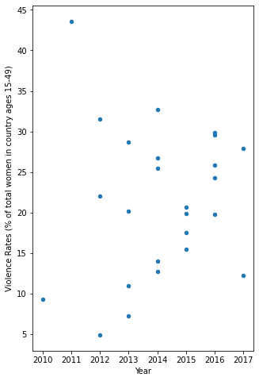

```python
# The code below "melts" the data so that all of the years are in a single column and are easier
# to work with.
melted_violence_df = pd.melt(africa_violence,
                        ["country"],
                        var_name = "year",
                        value_name = "rate of violence")

# Drawing a graph and storing the result.
scatter = melted_violence_df.plot.scatter(x='year', y='rate of violence', figsize=(5,8))
scatter.set_ylabel("Violence Rates (% of total women in country ages 15-49)")
scatter.set_xlabel("Year")
```

The scatter plot shown above is helpful for seeing general trends in rates of women subject to violence on the African continent. To get more detailed information, we'll look at the bar graph shown below which displays the proportion of women subject to violence by country and year.

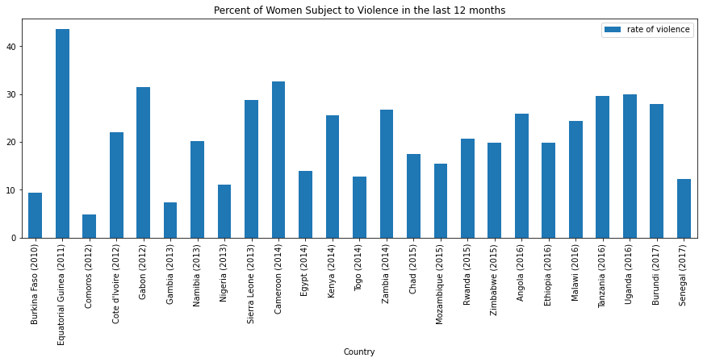

```python
violence_present_df = melted_violence_df.dropna()
violence_present_df = violence_present_df.astype({"year":str, "country":str})
violence_present_df["Country"] = violence_present_df["country"] + " (" + violence_present_df["year"] + ")"
violence_present_df.plot(x='Country', y='rate of violence', kind='bar', figsize=(15,5),
                        title="Percent of Women Subject to Violence in the last 12 months")
```

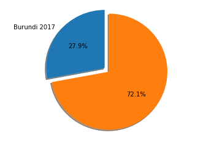

```python
# Getting data for Burundi.
violence_present_df.loc[violence_present_df['country']=='Burundi']

# Pie chart, where the slices will be ordered and plotted counter-clockwise:
labels = 'Burundi 2017', ' '
sizes = [27.9, 72.1]
explode = (0.1, 0)  # only "explode" the 1st slice

fig1, ax1 = plt.subplots()
ax1.pie(sizes, explode=explode, labels=labels, autopct='%1.1f%%',
        shadow=True, startangle=90)
ax1.axis('equal')  # Equal aspect ratio ensures that pie is drawn as a circle.

plt.show()
```

The pie chart above represents the 27.9% of women were subject to violence in Burundi in 2017. This is the highest rate of violence for the most recent year we see in our data. To get a better idea of how accurate this data is, we will explore a dataset containing information on the proportion of women who believe their husbands are justified in beating them for one of five reasons: arguing with him, burning the food, negelcting the children, going out without telling him, refusing him sex.

### Looking at "Justified" Violence

```python
# Tidying the dataframe of justified violence.
justified_violence = pd.melt(justified_violence,
                        ["country"],
                        var_name = "year",
                        value_name = "rate of violence")
justified_violence = justified_violence.dropna()
```

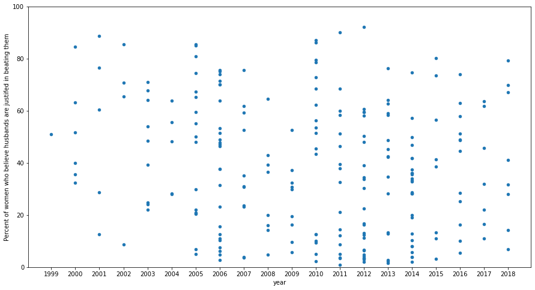

```python
# Scatter plot. Drawing a graph and storing the result.
scatter = justified_violence.plot.scatter(x='year', y='rate of violence', figsize=(15,8), ylim=(0.0, 100.0))
scatter.set_ylabel("Percent of women who believe husbands are justifed in beating them")
scatter.set_xlabel("year")
```

In the chart displayed above is the percent of women who believe their husbands are justified in beating them for one of the five reasons previously mentioned. I thought it was significant to include data from before 2010 to demonstrate how this trend has not changed over time, as some other trends have. I predict that countries in which this indicator was high in 1999, are countries that still have high rates of both this indicator and overall violence against women.

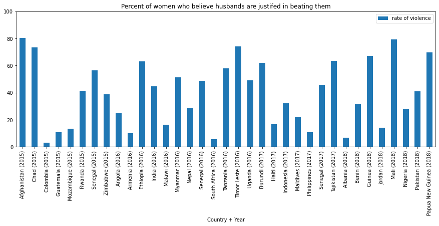

```python
# Bar graph.
# Using the last 10 years of data.
for index, row in justified_violence.iterrows():
    if int(row['year']) < 2015:
        justified_violence = justified_violence.drop(index)

justified_violence = justified_violence.astype({"year":str, "country":str})
justified_violence["Country + Year"] = justified_violence["country"] + " (" + justified_violence["year"] + ")"
justified_violence.plot(x='Country + Year', y='rate of violence', kind='bar', figsize=(15,5), ylim=(0.0, 100.0),
                        title="Percent of women who believe husbands are justifed in beating them")
```

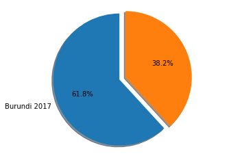

```python
# Getting data for Burundi
justified_violence.loc[justified_violence['country']=='Burundi']

# Pie chart, where the slices will be ordered and plotted counter-clockwise:
labels = 'Burundi 2017', ' '
sizes = [61.8, 38.2]
explode = (0.1, 0)  # only "explode" the 1st slice

fig1, ax1 = plt.subplots()
ax1.pie(sizes, explode=explode, labels=labels, autopct='%1.1f%%',
        shadow=True, startangle=90)
ax1.axis('equal')  # Equal aspect ratio ensures that pie is drawn as a circle.

plt.show()
```

The pie chart above represents the 61.8% of women in Burundi in 2017 who believed their husbands were justified in beating them for either arguing with him, burning the food, negelcting the children, going out without telling him, or refusing him sex. This is significantly different from the 27.9% of women who had reported experiencing physical or sexual violence in that same year. This leads me to believe that there was underreporting in the dataset with information on the percentage of women who had been subject to physical or sexual violence within the last 12 months.

### Literacy Rates

Displayed in the bar graphs below are the 10 lowest and highest ratios of females to males who are literate. In the study which the data was derived from, literacy was defined as being able to read and write short statements about their everyday lives. The ages of those surveyed range from 15-24, and the data used was from the years 2000-2010. In the second graph, displaying the countries with the 10 highest proportions, you will notice that the ratio exceeds 1.0. This could be due to there being a greater number of women in the population than men.

```python
literacy_rates = pd.melt(literacy_rates,
                        ["country"],
                        var_name = "year",
                        value_name = "literacy rate")
literacy_rates = literacy_rates.dropna()

# Using the most recent 10 years of data.
for index, row in literacy_rates.iterrows():
    if int(row['year']) < 2000:
        literacy_rates = literacy_rates.drop(index)
#     if row['country'] not in African_countries:
#         literacy_rates = literacy_rates.drop(index)
for index, row in literacy_rates.iterrows():
    if row['country'] not in African_countries:
        literacy_rates = literacy_rates.drop(index)
```

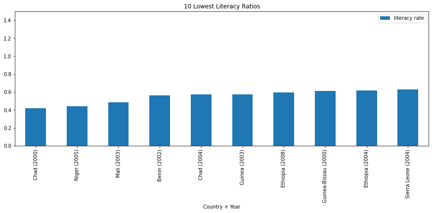

```python
# Gets the 10 lowest literacy rates from the year 2000-2010.

lowest_lit_df = literacy_rates.nsmallest(10, ['literacy rate'])
lowest_lit_df = lowest_lit_df.astype({"year":str, "country":str})
lowest_lit_df["Country + Year"] = lowest_lit_df["country"] + " (" + lowest_lit_df["year"] + ")"
lowest_lit_df.plot(x='Country + Year', y='literacy rate', kind='bar', figsize=(15,5),ylim=(0.0, 1.5),
                   title="10 Lowest Literacy Ratios")
```

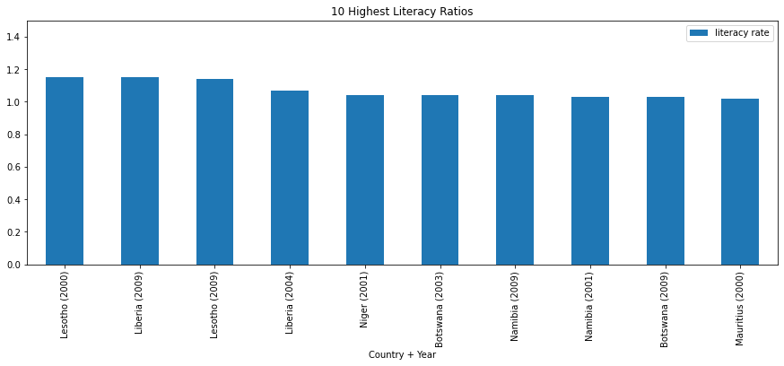

```python
# Gets the 10 highest literacy rates from the year 2000-2010.

highest_lit_df = literacy_rates.nlargest(10, ['literacy rate'])
highest_lit_df = highest_lit_df.astype({"year":str, "country":str})
highest_lit_df["Country + Year"] = highest_lit_df["country"] + " (" + highest_lit_df["year"] + ")"
highest_lit_df.plot(x='Country + Year', y='literacy rate', kind='bar', figsize=(15,5),ylim=(0.0, 1.5),
                   title="10 Highest Literacy Ratios")
```

### Relationship between oil rents and rates of violence

In this section I am going to use a dataset with information on the proportion of women who have been subject to violence and merge this information into a dataframe that contains values representing the percentage of a country's GDP that comes from oil rents. I predict that there will be a correlation between countries with large amounts of oil revenues and rates of women subject to violence.

```python
# Tidying up the GDP data so that it is easier to look at various indicators. Examples of indicators in this dataset
# include oil rents, total natural resource rents, and mineral rents as a percent of each country's total GDP.
gdp_df = gdp_df.drop(["COUNTRY", "INDICATOR", "TABLE", "YEAR", "Flag Codes", "Flags"], axis = 1)

# Using only the countries in Africa.
africa_gdp_df = gdp_df.loc[gdp_df["Country"].isin(African_countries)]

# Isolating the oil rents indicator so that it is the only one in the current dataframe.
oil_rents_df = africa_gdp_df.loc[gdp_df["Indicator"]== "Oil rents (% of GDP)"]

# Changing column names to accurately reflect its values and dropping unnecessary columns.
oil_rents_df = oil_rents_df.rename(columns={"Value":"Oil rents (% of GDP)"})
oil_rents_df = oil_rents_df.drop(["Indicator", "Table name"], axis = 1)
```

```python
### Temporary work ###

# Using the last 10 years of data.
# oil_rents_df = oil_rents_df.reset_index()
# year_list = [*range(2000,2010)]

# print(year_list)
# for i in range(len(oil_rents_df)):
#     if oil_rents_df['Year'].iloc[i] in (year_list):
#         oil_rents_df = oil_rents_df.drop([i], inplace=True, axis=0)
```

```python
# Tidying the rates of violence data so that we can more easily merge it.
melted_violence_df = melted_violence_df.rename(columns={"country":"Country", "year":"Year"})

# Combining datasets to see if there is a realtionship between oil rents and rates of violence.
oil_to_violence_df = melted_violence_df.merge(oil_rents_df, on=["Country", "Year"], how="inner")

# dropping rows with nans
oil_to_violence_df = oil_to_violence_df.dropna()

# Preparing to display the two dataframes side by side.
df1 = oil_to_violence_df.sort_values(ascending=False, by=["Oil rents (% of GDP)"])
df2 = oil_rents_df.sort_values(ascending=False, by=["Oil rents (% of GDP)"])[:13]

df1_styler = df1.style.set_table_attributes("style='display:inline'").set_caption('Oil and Violence')
df2_styler = df2.style.set_table_attributes("style='display:inline'").set_caption('Oil Rents')
```

```python
display_html(df1_styler._repr_html_() + " .   .   .   ." + df2_styler._repr_html_(), raw=True)
```

Oil and Violence

|  | Country | Year | rate of violence | Oil rents (% of GDP) |
| --- | --- | --- | --- | --- |
| 64 | Egypt | 2014 | 14.000000 | 6.754000 |
| 62 | Cameroon | 2014 | 32.700000 | 4.369000 |
| 0 | Burkina Faso | 2010 | 9.300000 | 0.000000 |
| 33 | Comoros | 2012 | 4.900000 | 0.000000 |
| 51 | Gambia | 2013 | 7.300000 | 0.000000 |
| 68 | Kenya | 2014 | 25.500000 | 0.000000 |
| 86 | Rwanda | 2015 | 20.700000 | 0.000000 |
| 89 | Zimbabwe | 2015 | 19.900000 | 0.000000 |
| 95 | Ethiopia | 2016 | 19.800000 | 0.000000 |
| 99 | Malawi | 2016 | 24.300000 | 0.000000 |
| 103 | Uganda | 2016 | 29.900000 | 0.000000 |
| 106 | Burundi | 2017 | 27.900000 | 0.000000 |
| 117 | Senegal | 2017 | 12.200000 | 0.000000 |

. . . .

Oil Rents

|  | Country | Year | Oil rents (% of GDP) |
| --- | --- | --- | --- |
| 80098 | Sudan | 2008 | 22.913000 |
| 80101 | Sudan | 2011 | 18.380000 |
| 80097 | Sudan | 2007 | 18.247000 |
| 80095 | Sudan | 2005 | 17.405000 |
| 80096 | Sudan | 2006 | 16.988000 |
| 80100 | Sudan | 2010 | 13.610000 |
| 80094 | Sudan | 2004 | 13.448000 |
| 120531 | Egypt | 2008 | 12.469000 |
| 120528 | Egypt | 2005 | 12.193000 |
| 120529 | Egypt | 2006 | 12.106000 |
| 80099 | Sudan | 2009 | 11.028000 |
| 120530 | Egypt | 2007 | 10.958000 |
| 80090 | Sudan | 2000 | 10.138000 |

### Relationship between the percent of women in parliament and other indicators

```python
# Adding the proper column headings to the women in parliament dataset.
col_list = parliament_df.iloc[2]
for i in range(len(col_list)):
    if(type(col_list[i]) == np.float64):
        col_list[i] = int(col_list[i])
parliament_df.columns = col_list

# Dropping the first three rows which don't contain data.
parliament_df = parliament_df.iloc[3:]
parliament_df = parliament_df.reset_index()
parliament_df = parliament_df.drop(['Country Code', 'Indicator Name', 'Indicator Code','index'],axis = 1)

# Using only the countries in Africa.
parliament_df = parliament_df.loc[parliament_df["Country Name"].isin(African_countries)]
```

```python
# Melting the dataset to have a years column.
melted_parliament_df = pd.melt(parliament_df,
                        ["Country Name"],
                        var_name = "Year",
                        value_name = "Women in Parliament (%)")

par_by_country_df = melted_parliament_df.groupby('Country Name')['Women in Parliament (%)']
```

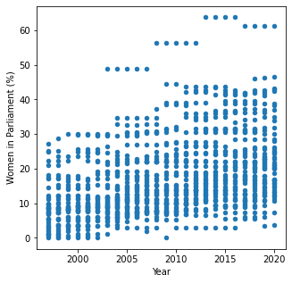

```python
melted_parliament_df
# Drawing a graph and storing the result.
scatter2 = melted_parliament_df.plot.scatter(x='Year', y='Women in Parliament (%)', figsize=(5,5))
scatter2.set_ylabel("Women in Parliament (%)")
scatter2.set_xlabel("Year")
```

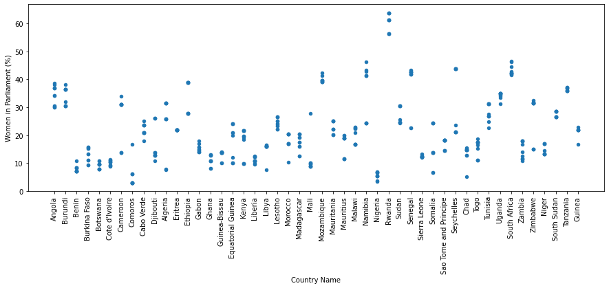

```python
# Dropping rows without values.
parliament_present_df = melted_parliament_df.dropna()

# Using the last 10 years of data.
for index, row in parliament_present_df.iterrows():
    if row['Year'] < 2010:
        parliament_present_df = parliament_present_df.drop(index)

parliament_present_df = parliament_present_df.astype({"Year":str, "Country Name":str})
parliament_present_df["Country"] = parliament_present_df["Country Name"] + " (" + parliament_present_df["Year"] + ")"
parliament_present_df.plot(x='Country Name', y='Women in Parliament (%)', kind='scatter', figsize=(15,5),rot=90)
```

```python
# Grouped by the median percent of woemen in parliament for the last 10 years. I beleive that using the
# median as a measure of center more accurately reflects trends in the countries during this time as averages
# can be easily skewed.
grouped_par_df = parliament_present_df.groupby("Country Name")['Women in Parliament (%)'].median()

grouped_par_df = grouped_par_df.to_frame()
grouped_par_df.head()
```

| Country Name | Women in Parliament (%) |
| --- | --- |
| Algeria | 25.757576 |
| Angola | 34.090909 |
| Benin | 7.228916 |
| Botswana | 9.523810 |
| Burkina Faso | 13.385827 |

```python
violence_present_df = violence_present_df.rename(columns={"country":"Country Name"})
```

```python
par_vi_df = violence_present_df.merge(grouped_par_df, on=["Country Name"], how="inner")
```

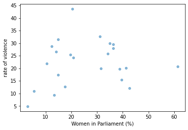

```python
par_vi_df.plot.scatter(x="Women in Parliament (%)", y="rate of violence", alpha=.5)

# unexpected but we need to look at more data.
```

###### Sources

https://www.gapminder.org/data/  
Ratio of females to males who are between the ages of 15 and 24 and literate. Literacy is being defined as being able to understand, read, and write simple sentences on their everday life. Used in this notebook as 'literacy_rates'.

https://stats.oecd.org/Index.aspx?DataSetCode=AEO11_COUNTRYNOTES_TAB2_EN#  
World data on various indicators including but not limited to:  
'Gross domestic product in U.S. dollars'  
'GDP in purchasing power parity (PPP) dollars per capita'  
'Employment as % of population 15+ (Females)'  
'Total natural resources rents (% of GDP)'  
'Percentage of Individuals using the Internet'  
'Agriculture, forestry, and fishing, value added (% of GDP)'  
'Oil rents (% of GDP)'  
'Mineral rents (% of GDP)'  
'Gender Development Index (GDI)'  
'Freedom to make life choices'  
'Employment in services as % of total'  
'Gender Inequality Index (GII)'

https://data.unicef.org/topic/child-protection/violence/attitudes-and-social-norms-on-violence/  
women who believe husbands are justified in beating their wife for any of the following 5 reasons: arguing with him, burning the food, negelcting the children, going out without telling him, or refusing him sex.

https://apps.who.int/gho/data/view.main.IPVv  
Proportion of women who have beeen subject to physical or sexual violence in the last 12 months. The percent of women ages 15-49.

https://data.worldbank.org/indicator/SG.GEN.PARL.ZS  
World Bank data on Proportion of seats held by women in national parliaments (%). 1997-2020.

### To be continued...

For the final version of my project, I am considering going more in depth and looking into the relationships between the rates of women who believed that violence was justified and what sector the largest percent of a country's GDP comes from. I have started doing this in the code shown below, however this data is not ready to be looked at yet!

```python
oil_gdp_recent_df = oil_gdp_recent_df.drop(["Series Code", "Country Code", "1990 [YR1990]", "2000 [YR2000]"], axis = 1)

# Tidying the more recent oil rents data.
for index, row in oil_gdp_recent_df.iterrows():
    if row['Series Name'] != 'Oil rents (% of GDP)':
        oil_gdp_recent_df = oil_gdp_recent_df.drop(index)
oil_gdp_recent_df = oil_gdp_recent_df.drop(["Series Name"], axis = 1)

oil_gdp_df = pd.melt(oil_gdp_recent_df,
                        ["Country Name"],
                        var_name = "Year",
                        value_name = "Oil Rents (% of GDP)")
```

```python
# Changing the Year values to be labled correctly.
for index, row in oil_gdp_df.iterrows():
    row['Year'] = row['Year'][:4]
```

```python
# Using the last 10 years of data for the oil rents as a percent of GDP data.
for index, row in oil_rents_df.iterrows():
    if row['Year'] == 'Latest available year':
        oil_rents_df = oil_rents_df.drop(index)
    elif int(row['Year']) < 2010:
        oil_rents_df = oil_rents_df.drop(index)

# Tidying the parliament data so that we can more easily merge it.
parliament_present_df = parliament_present_df.rename(columns={"Country":"Country+Year", "Country Name":"Country"})

# Combining datasets to see if there is a realtionship between oil rents and rates of violence.
oil_and_par_df = parliament_present_df.merge(oil_rents_df, on=["Country", "Year"], how="outer")
#oil_and_par_df.dropna()
```

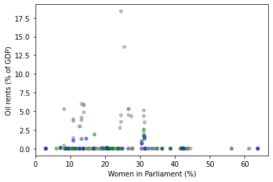

```python
#oil_and_par_df.loc[oil_and_par_df["Country"]=="Rwanda"]

cols = oil_and_par_df["Year"].map({
    "2010": "grey","2011": "grey","2012": "grey",
    "2013": "grey","2014": "grey","2015": "grey",
    np.nan: "grey",
    "2016": "blue",
    "2017": "green",
    "2018": "green",
    "2019": "orange",
    "2020": "red"

})

oil_and_par_df.plot.scatter(x="Women in Parliament (%)", y="Oil rents (% of GDP)",
                        c=cols, alpha=.5)
```

```python
# grouped_par_df
# grouped_par_df = parliament_present_df.groupby("Country Name")['Women in Parliament (%)'].median()

# grouped_par_df = grouped_par_df.to_frame()
# grouped_par_df.head()
```